# Project

Seth Hodgkins

12/15/2020

## Temperatures affect on Crime

Here I plotted the number of Crimes at each temperature. I wanted to see if when the weather was hotter there were more crimes.

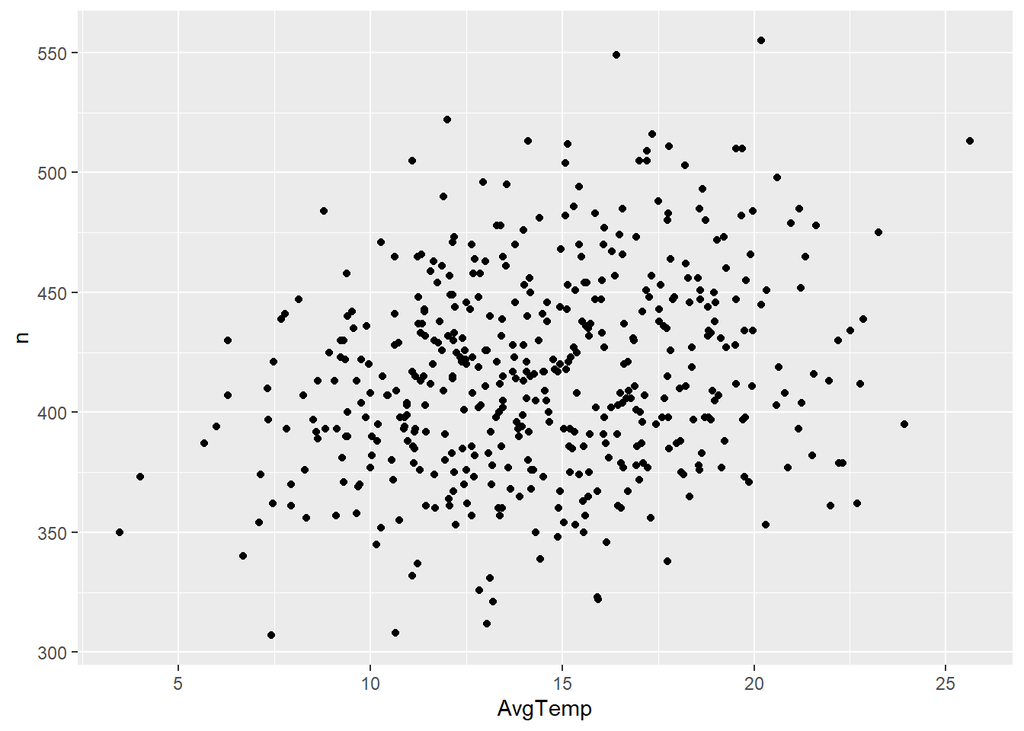

Next I made a simple linear model to show the relationship. It seems to be positively correlated.

```
## (Intercept)     AvgTemp
##  378.257837    2.609722
```

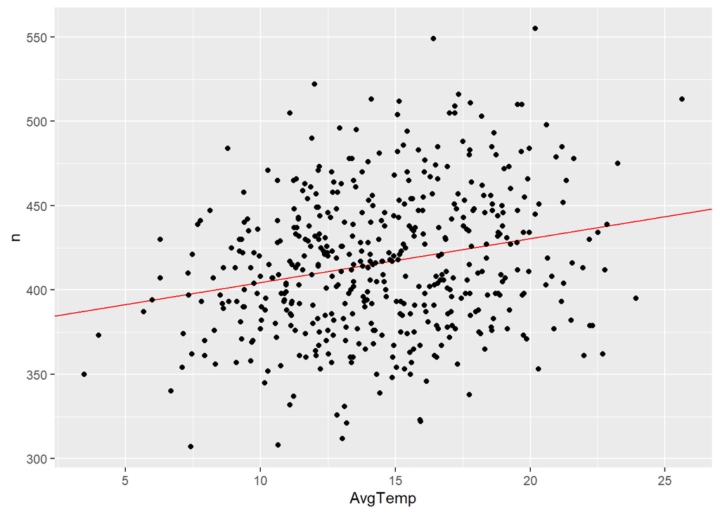

The residual doesn’t seem to follow any sort of pattern, it seems pretty random.

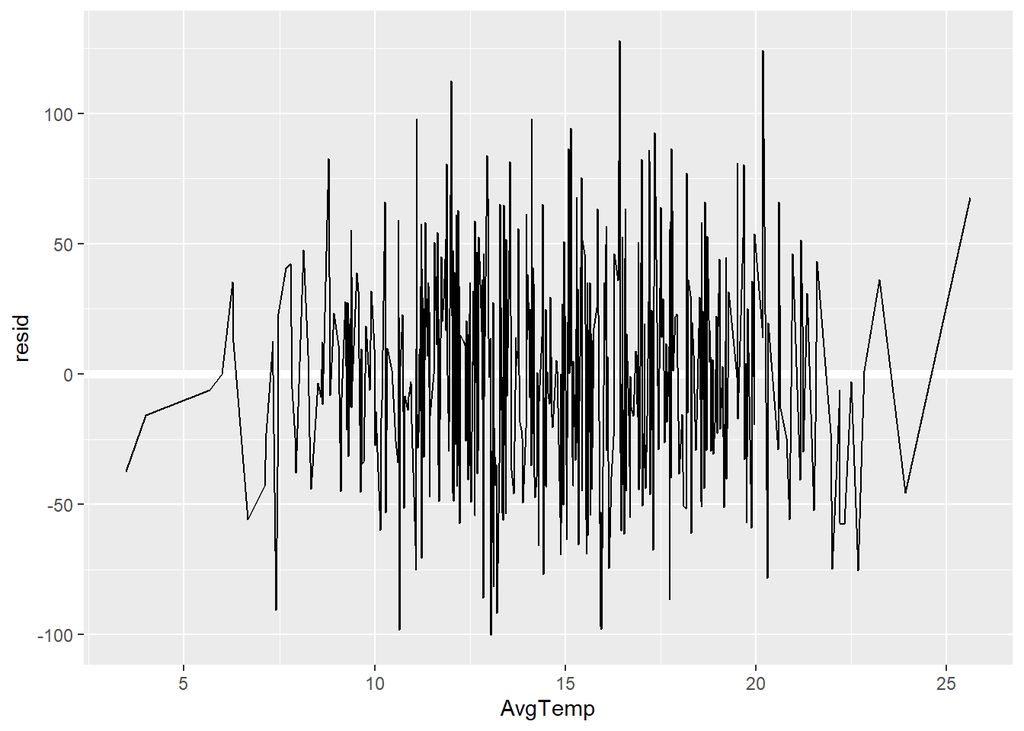

I will do this by…

- rounding each temperature to the nearest degree so we have many data points at each temperature increment
- adding up the number of crimes in each degree
- dividing the crimes in each row by the number of days with that temperature

Here is the plot. It is much more readable and shows a more clear linear trend. For some reason it seems to peak and then drop off at 20. Maybe after that it gets too hot for even the criminals.

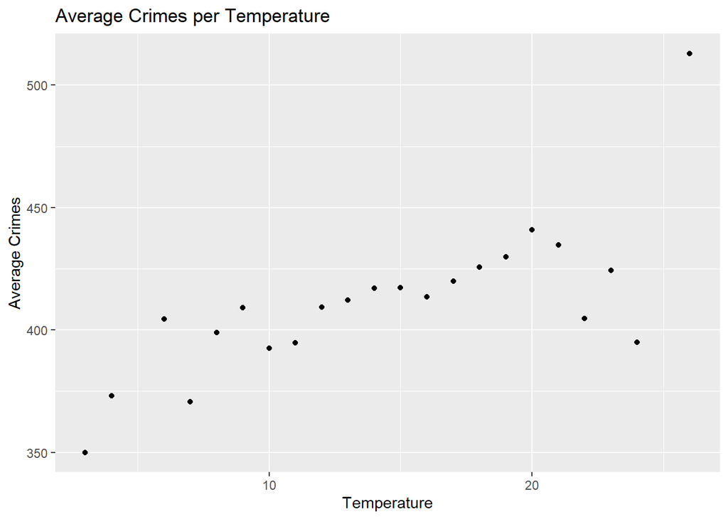

```
## (Intercept)     AvgTemp
##  361.757525    3.434182
```

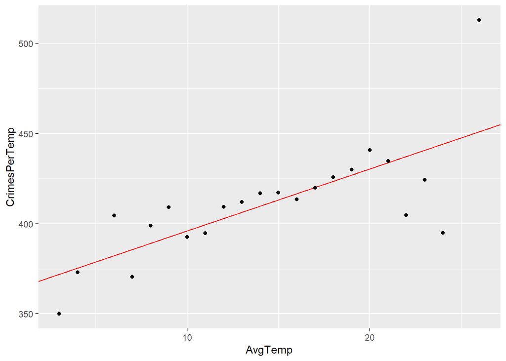

## Crimes Over Time

Here I have plotted the number of crimes each day. It doesn’t look to follow any sort of mathematical model, the closest thing would be linear or a parabola though I doubt crime in San Francisco follows a parabola shape. I want to see if I can get rid of some of the apparent noise.

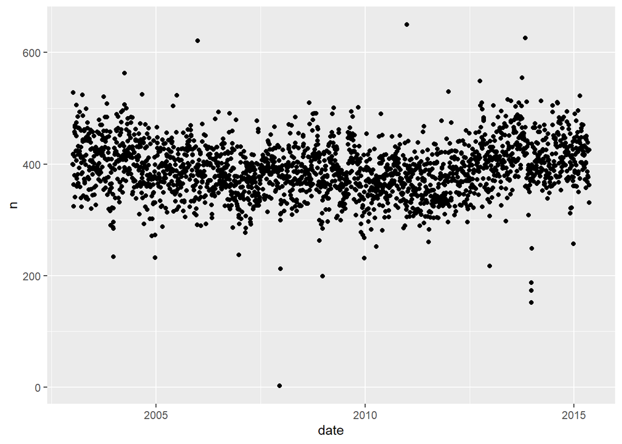

I thought that it would be good to look for any patterns in the days, weeks, months, and years that could explain the noise.

I started with weekdays. There seems to be an upward trend as the week progresses, peaking at Friday before going back down Saturday and Sunday.

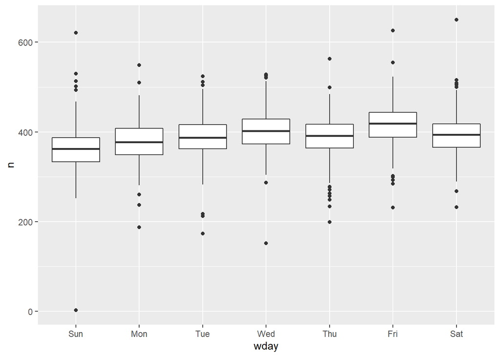

Next I tried the day of Month, something looks a little strange with the first of every month. There is a large peak. This could be because police just put down the 1st of the month when they are feeling lazy more often than any other day. This is a perfect example of something that should be taken out in the model.

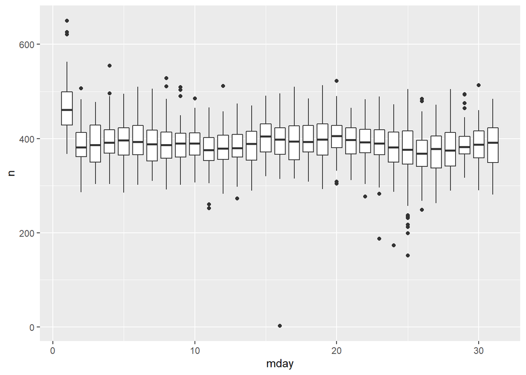

Moving up we have month of year. It seems like it stays steady before October, after which it plummets, and then goes back to normal levels in January.

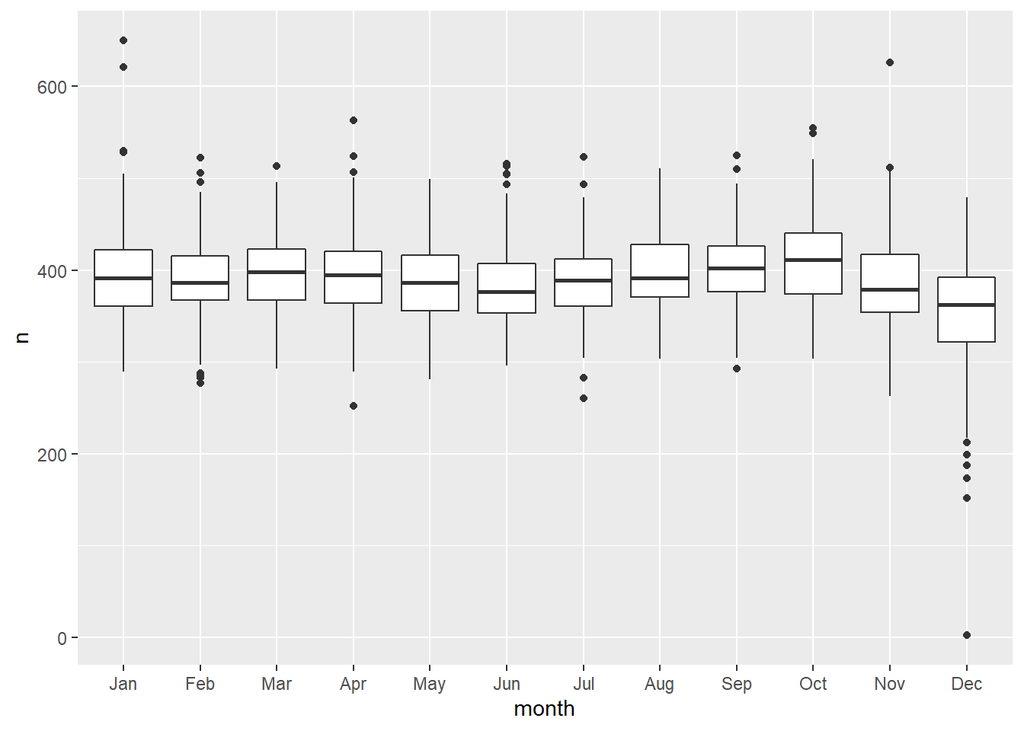

Lastly we have days of the year. There seems to be a very strong pattern of gaps, maybe between the months? I’m not sure why.

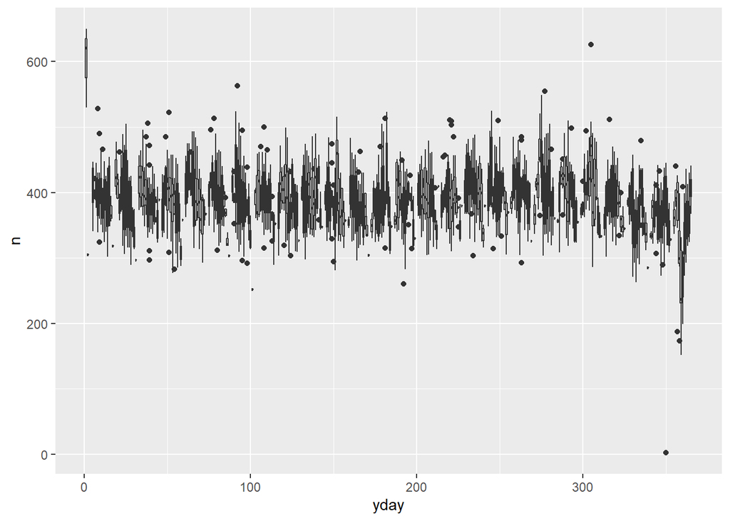

Next I removed all the patterns I just found. Day of week, day of month, and month of year.

```
##   (Intercept)          date
## 370.985724915   0.001357645
```

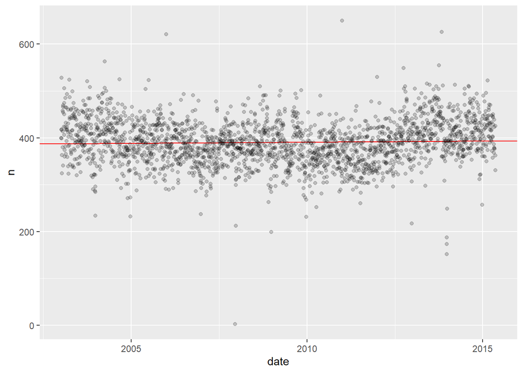

I couldn’t think of another model so I thought it could be interesting to make a weather model. I immediately recognized a cosine wave.

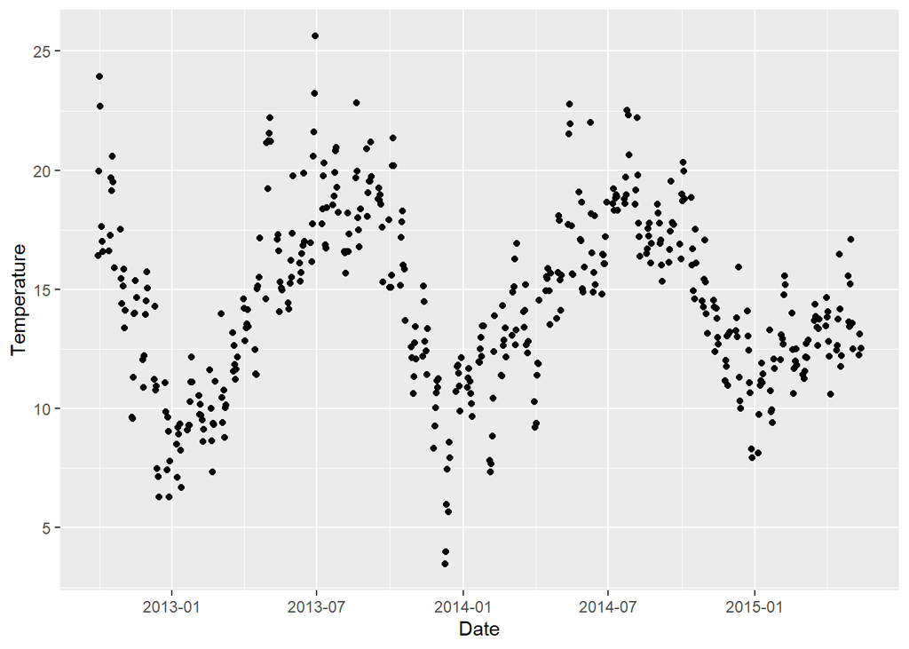

I couldn’t figure out an automated way to get a cosine model for this relationship so I made my own. It describes the pattern fairly well.

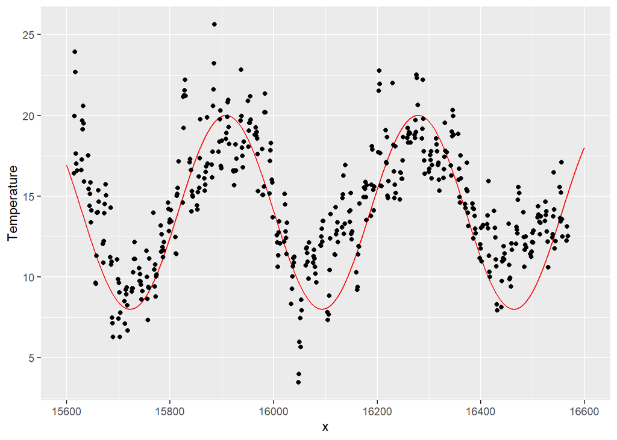